# Statistical Machine Learning Project

Predicting health insurance premium

Milad Zaman

The aim of this project is to build predictive models to estimate the **medical insurance premium price** for individuals based on their **health-related** and **demographic features**. We compare multiple machine learning models—including linear regression, decision trees, ensemble methods, and neural networks—to identify the model with the best prediction performance

```r
library(readr)
library(dplyr)
library(psych)

# Load the CSV file
data <- read_csv("C:/Users/Lenovo/Downloads/Documents/Medical Insurance.csv")
```

# Exploratory Data Analysis (EDA)

## Data structure

```r
# Check structure of the dataset
str(data)
```

```
spc_tbl_ [986 × 11] (S3: spec_tbl_df/tbl_df/tbl/data.frame)
 $ Age                    : num [1:986] 45 60 36 52 38 30 33 23 48 38 ...
 $ Diabetes               : num [1:986] 0 1 1 1 0 0 0 0 1 0 ...
 $ BloodPressureProblems  : num [1:986] 0 0 1 1 0 0 0 0 0 0 ...
 $ AnyTransplants         : num [1:986] 0 0 0 0 0 0 0 0 0 0 ...
 $ AnyChronicDiseases     : num [1:986] 0 0 0 1 1 0 0 0 0 0 ...
 $ Height                 : num [1:986] 155 180 158 183 166 160 150 181 169 182 ...
 $ Weight                 : num [1:986] 57 73 59 93 88 69 54 79 74 93 ...
 $ KnownAllergies         : num [1:986] 0 0 0 0 0 1 0 1 1 0 ...
 $ HistoryOfCancerInFamily: num [1:986] 0 0 0 0 0 0 0 0 0 0 ...
 $ NumberOfMajorSurgeries : num [1:986] 0 0 1 2 1 1 0 0 0 0 ...
 $ PremiumPrice           : num [1:986] 25000 29000 23000 28000 23000 23000 21000 15000 23000 23000 ...
 - attr(*, "spec")=
  .. cols(
  ..   Age = col_double(),
  ..   Diabetes = col_double(),
  ..   BloodPressureProblems = col_double(),
  ..   AnyTransplants = col_double(),
  ..   AnyChronicDiseases = col_double(),
  ..   Height = col_double(),
  ..   Weight = col_double(),
  ..   KnownAllergies = col_double(),
  ..   HistoryOfCancerInFamily = col_double(),
  ..   NumberOfMajorSurgeries = col_double(),
  ..   PremiumPrice = col_double()
  .. )
 - attr(*, "problems")=<externalptr>
```

```r
# View the first few rows
head(data)
```

| Age | Diabetes | BloodPressureProblems | AnyTransplants | AnyChronicDiseases | Height | Weight | KnownAllergies | HistoryOfCancerInFamily | NumberOfMajorSurgeries | PremiumPrice |
| --- | --- | --- | --- | --- | --- | --- | --- | --- | --- | --- |
| 45 | 0 | 0 | 0 | 0 | 155 | 57 | 0 | 0 | 0 | 25000 |
| 60 | 1 | 0 | 0 | 0 | 180 | 73 | 0 | 0 | 0 | 29000 |
| 36 | 1 | 1 | 0 | 0 | 158 | 59 | 0 | 0 | 1 | 23000 |
| 52 | 1 | 1 | 0 | 1 | 183 | 93 | 0 | 0 | 2 | 28000 |
| 38 | 0 | 0 | 0 | 1 | 166 | 88 | 0 | 0 | 1 | 23000 |
| 30 | 0 | 0 | 0 | 0 | 160 | 69 | 1 | 0 | 1 | 23000 |

```r
# View the last few rows
tail(data)
```

| Age | Diabetes | BloodPressureProblems | AnyTransplants | AnyChronicDiseases | Height | Weight | KnownAllergies | HistoryOfCancerInFamily | NumberOfMajorSurgeries | PremiumPrice |
| --- | --- | --- | --- | --- | --- | --- | --- | --- | --- | --- |
| 40 | 0 | 1 | 1 | 0 | 171 | 74 | 0 | 0 | 0 | 38000 |
| 18 | 0 | 0 | 0 | 0 | 169 | 67 | 0 | 0 | 0 | 15000 |
| 64 | 1 | 1 | 0 | 0 | 153 | 70 | 0 | 0 | 3 | 28000 |
| 56 | 0 | 1 | 0 | 0 | 155 | 71 | 0 | 0 | 1 | 29000 |
| 47 | 1 | 1 | 0 | 0 | 158 | 73 | 1 | 0 | 1 | 39000 |
| 21 | 0 | 0 | 0 | 0 | 158 | 75 | 1 | 0 | 1 | 15000 |

```r
# Get basic descriptive stats for columns
describe(data)
```

|  | vars | n | mean | sd | median | trimmed | mad | min | max | range | skew | kurtosis | se |
| --- | --- | --- | --- | --- | --- | --- | --- | --- | --- | --- | --- | --- | --- |
| Age | 1 | 986 | 41.75 | 13.96 | 42 | 41.69 | 17.79 | 18 | 66 | 48 | 0.03 | -1.14 | 0.44 |
| Diabetes | 2 | 986 | 0.42 | 0.49 | 0 | 0.40 | 0.00 | 0 | 1 | 1 | 0.32 | -1.90 | 0.02 |
| BloodPressureProblems | 3 | 986 | 0.47 | 0.50 | 0 | 0.46 | 0.00 | 0 | 1 | 1 | 0.13 | -1.99 | 0.02 |
| AnyTransplants | 4 | 986 | 0.06 | 0.23 | 0 | 0.00 | 0.00 | 0 | 1 | 1 | 3.87 | 12.95 | 0.01 |
| AnyChronicDiseases | 5 | 986 | 0.18 | 0.38 | 0 | 0.10 | 0.00 | 0 | 1 | 1 | 1.66 | 0.75 | 0.01 |
| Height | 6 | 986 | 168.18 | 10.10 | 168 | 168.45 | 11.86 | 145 | 188 | 43 | -0.18 | -0.77 | 0.32 |
| Weight | 7 | 986 | 76.95 | 14.27 | 75 | 76.22 | 14.08 | 51 | 132 | 81 | 0.66 | 0.59 | 0.45 |
| KnownAllergies | 8 | 986 | 0.22 | 0.41 | 0 | 0.14 | 0.00 | 0 | 1 | 1 | 1.39 | -0.08 | 0.01 |
| HistoryOfCancerInFamily | 9 | 986 | 0.12 | 0.32 | 0 | 0.02 | 0.00 | 0 | 1 | 1 | 2.37 | 3.62 | 0.01 |
| NumberOfMajorSurgeries | 10 | 986 | 0.67 | 0.75 | 1 | 0.56 | 1.48 | 0 | 3 | 3 | 0.86 | 0.05 | 0.02 |

[output cut: 1 more lines]

```r
# Check for Missing Values
colSums(is.na(data))
```

```
                    Age                Diabetes   BloodPressureProblems          AnyTransplants
                      0                       0                       0                       0
     AnyChronicDiseases                  Height                  Weight          KnownAllergies
                      0                       0                       0                       0
HistoryOfCancerInFamily  NumberOfMajorSurgeries            PremiumPrice
                      0                       0                       0
```

## Descriptive statistics and Visualization.

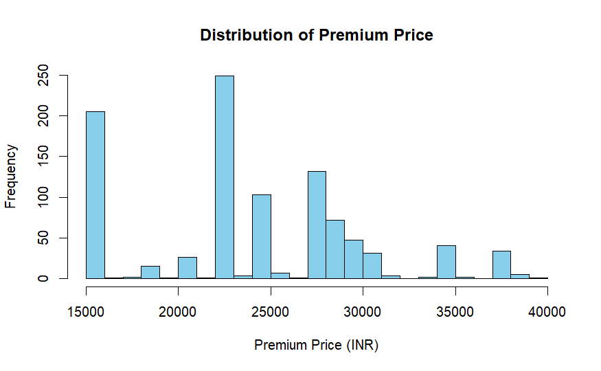

```r
# Histogram
hist(data$PremiumPrice,
     breaks = 30,
     col = "skyblue",
     main = "Distribution of Premium Price",
     xlab = "Premium Price (INR)")
```

```r
# Set plotting layout: 1 row, 3 columns
par(mfrow = c(1, 3))

# Boxplots for numeric variables
boxplot(data$PremiumPrice,
        main = "Premium Price",
        col = "lightgreen")
boxplot(data$Height,
        main = "Height",
        col = "lightblue")
```

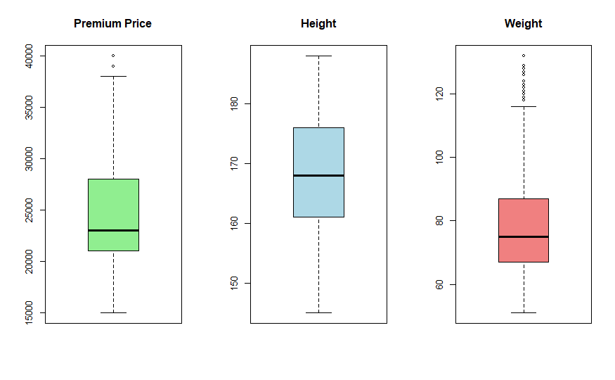

```r
boxplot(data$Weight,
        main = "Weight",
        col = "lightcoral")
# Reset layout to default
par(mfrow = c(1, 1))
```

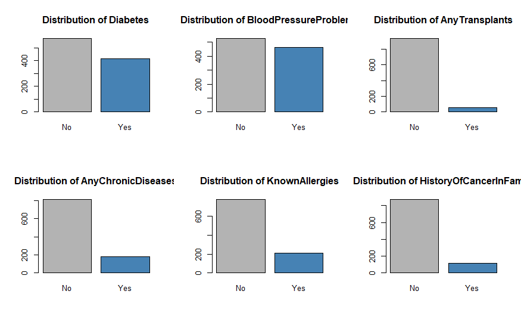

```r
# Loop through binary features for bar charts
binary_vars <- c("Diabetes", "BloodPressureProblems", "AnyTransplants",
                 "AnyChronicDiseases", "KnownAllergies",
                 "HistoryOfCancerInFamily")

par(mfrow = c(2, 3))  # Layout 2x3
for (var in binary_vars) {
  barplot(table(data[[var]]),
          main = paste("Distribution of", var),
          col = c("gray70", "steelblue"),
          names.arg = c("No", "Yes"))
}
par(mfrow = c(1, 1))  # Reset
```

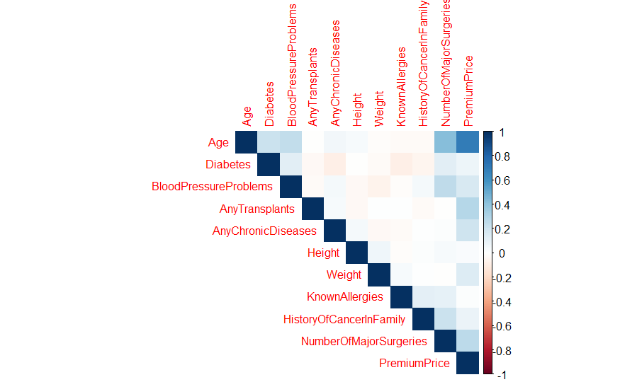

```r
#Correlation matrix
cor_matrix <- cor(data)

#Heatmap
library(corrplot)
corrplot(cor_matrix, method = "color", type = "upper", tl.cex = 0.8)
```

```r
par(mfrow = c(1, 2))
#Scatterplot: Weight vs Premium
plot(data$Weight, data$PremiumPrice,
     main = "Weight vs Premium Price",
     xlab = "Weight", ylab = "Premium Price",
     col = "darkgreen", pch = 19)
#Scatterplot: Age vs Premium
plot(data$Age, data$PremiumPrice,
     main = "Age vs Premium Price",
     xlab = "Age", ylab = "Premium Price", col = "darkred", pch = 19)
```

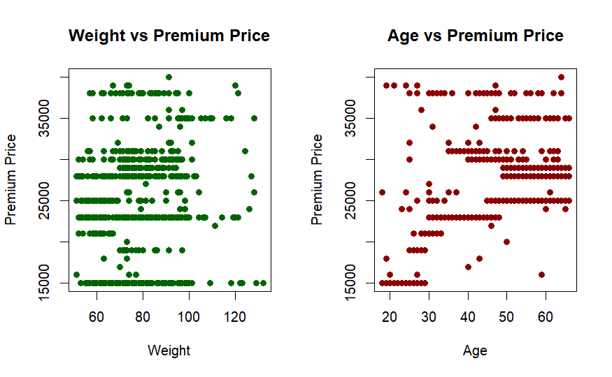

```r
par(mfrow = c(1, 1))
```

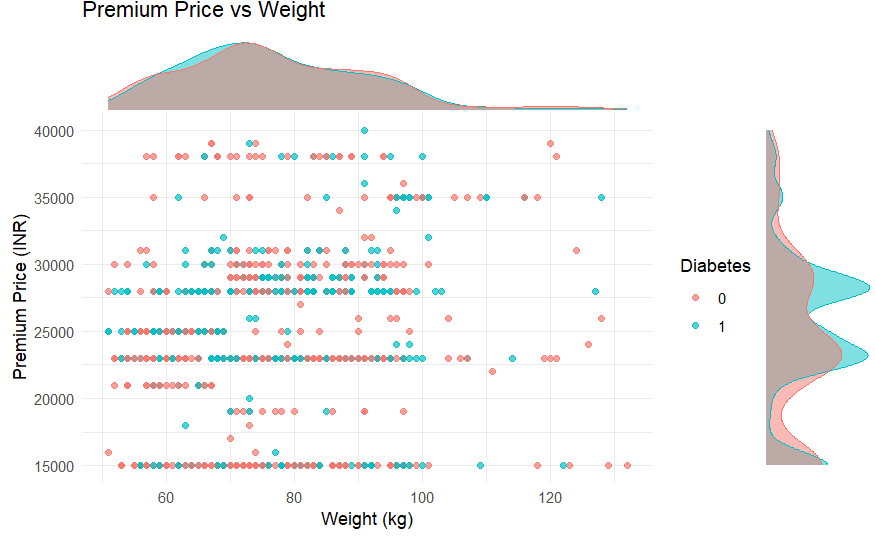

```r
library(ggplot2)
library(ggExtra)

# Convert Diabetes to factor
data$Diabetes <- as.factor(data$Diabetes)

# Base scatter plot
p <- ggplot(data, aes(x = Weight, y = PremiumPrice, color = Diabetes)) +
  geom_point(alpha = 0.7) +
  labs(
    title = "Premium Price vs Weight",
    x = "Weight (kg)",
    y = "Premium Price (INR)",
    color = "Diabetes"
  ) +
  theme_minimal()

# Add marginal density plots
ggMarginal(
  p,
  type = "density",
  groupColour = TRUE,
  groupFill = TRUE
)
```

# Models 1 & 2

```r
library(caret)
library(ggplot2)
library(lattice)
# Set seed for reproducibility
set.seed(123)

# Split data into training (80%) and test (20%)
trainIndex <- createDataPartition(data$PremiumPrice, p = 0.8, list = FALSE)
train <- data[trainIndex, ]
test <- data[-trainIndex, ]

# Normalize predictors for linear regression
preProc <- preProcess(train[, -11], method = c("center", "scale"))
train_norm <- predict(preProc, train[, -11])
test_norm <- predict(preProc, test[, -11])

# Add target variable back
train_final <- cbind(train_norm, PremiumPrice = train$PremiumPrice)
test_final <- cbind(test_norm, PremiumPrice = test$PremiumPrice)
```

## Linear Regression

```r
library(Metrics)  # For RMSE
model_lm <- train(PremiumPrice ~ ., data = train_final, method = "lm", trControl = trainControl(method = "cv", number = 5))

summary(model_lm)
```

```
Call:
lm(formula = .outcome ~ ., data = dat)

Residuals:
     Min       1Q   Median       3Q      Max
-13285.9  -2287.5   -345.8   1821.8  24198.6

Coefficients:
                        Estimate Std. Error t value Pr(>|t|)
(Intercept)             24567.70     185.46 132.467  < 2e-16 ***
Age                      4599.09     157.21  29.254  < 2e-16 ***
Diabetes1                -364.25     289.16  -1.260  0.20816
BloodPressureProblems      88.95     145.19   0.613  0.54031
AnyTransplants           1785.25     138.50  12.890  < 2e-16 ***
AnyChronicDiseases        991.23     139.44   7.109 2.65e-12 ***
Height                   -108.32     139.00  -0.779  0.43603
Weight                   1055.72     138.52   7.622 7.29e-14 ***
KnownAllergies             42.53     140.42   0.303  0.76206
HistoryOfCancerInFamily   762.02     143.11   5.325 1.32e-07 ***
NumberOfMajorSurgeries   -526.40     160.41  -3.282  0.00108 **
---
Signif. codes:  0 ‘***’ 0.001 ‘**’ 0.01 ‘*’ 0.05 ‘.’ 0.1 ‘ ’ 1

Residual standard error: 3874 on 779 degrees of freedom
Multiple R-squared:  0.6272,    Adjusted R-squared:  0.6224
F-statistic:   131 on 10 and 779 DF,  p-value: < 2.2e-16
```

The linear regression model explains approximately 63% of the variation in premium prices (R² = 0.627), indicating a reasonably good fit. Statistically significant predictors include Age, Weight, Transplants, Chronic Diseases, and Cancer History, which positively influence premium prices. Other variables such as Diabetes, Allergies, and Height were found to be statistically insignificant. Overall, the model is statistically significant (p < 2.2e-16) and provides meaningful insights into the factors affecting premium costs.

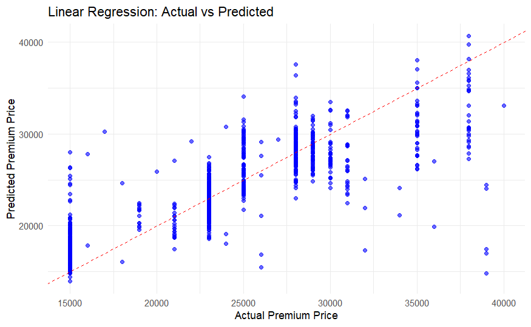

```r
# Predictions
pred_lm_train <- predict(model_lm, train_final)
pred_lm_cv_rmse <- model_lm$resample$RMSE

# Final evaluation
lm_train_rmse <- RMSE(pred_lm_train, train_final$PremiumPrice)

# Actual vs Predicted Plot
ggplot(data = train_final, aes(x = PremiumPrice, y = pred_lm_train)) +
  geom_point(color = "blue", alpha = 0.6) +
  geom_abline(intercept = 0, slope = 1, color = "red", linetype = "dashed") +
  labs(title = "Linear Regression: Actual vs Predicted",
       x = "Actual Premium Price",
       y = "Predicted Premium Price") +
  theme_minimal()
```

The blue dots generally follow the upward trend of the red dashed line. It means that as the actual premium price increases, the model’s predicted premium price also tends to increase. This suggests the model has learned some relationship in the data.

## Regression Tree

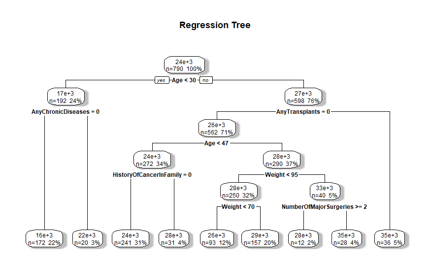

```r
library(rpart)
library(rpart.plot)

# Train regression tree on original (non-normalized) data
model_tree <- rpart(PremiumPrice ~ ., data = train, method = "anova")

# Plot the tree
prp(model_tree,
    type = 2,           # show variable names in splits
    extra = 101,        # show RMSE and samples in leaves
    fallen.leaves = TRUE,
    faclen = 0,         # do not abbreviate factor levels
    varlen = 0,         # do not abbreviate variable names
    shadow.col = "gray",   # Add shadow
    main = "Regression Tree")
```

Age is the most dominant feature, making the initial and most significant split in premium predictions. For younger individuals (Age < 30), AnyChronicDiseases is the next key factor. For older individuals, AnyTransplants, further Age distinctions (around 47), and Weight are highly influential.

```r
#print complexity parameter table
printcp(model_tree)
```

```
Regression tree:
rpart(formula = PremiumPrice ~ ., data = train, method = "anova")

Variables actually used in tree construction:
[1] Age                     AnyChronicDiseases      AnyTransplants          HistoryOfCancerInFamily
[5] NumberOfMajorSurgeries  Weight

Root node error: 3.1361e+10/790 = 39697845

n= 790

        CP nsplit rel error  xerror     xstd
1 0.484463      0   1.00000 1.00628 0.044609
2 0.088672      1   0.51554 0.51842 0.045956
3 0.079175      2   0.42686 0.47282 0.045824
4 0.026898      3   0.34769 0.35246 0.044142
5 0.017289      4   0.32079 0.33429 0.044118
6 0.015197      5   0.30350 0.33338 0.045604
7 0.014590      6   0.28831 0.32706 0.045628
8 0.011819      7   0.27372 0.30381 0.045440
9 0.010000      8   0.26190 0.28773 0.044273
```

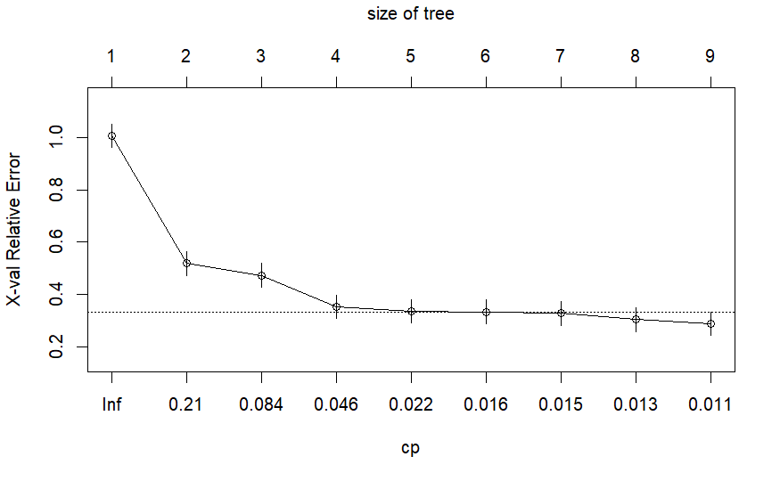

```r
#plot of cross-validation error vs. tree complexity.
plotcp(model_tree)
```

### Complexity and Pruning

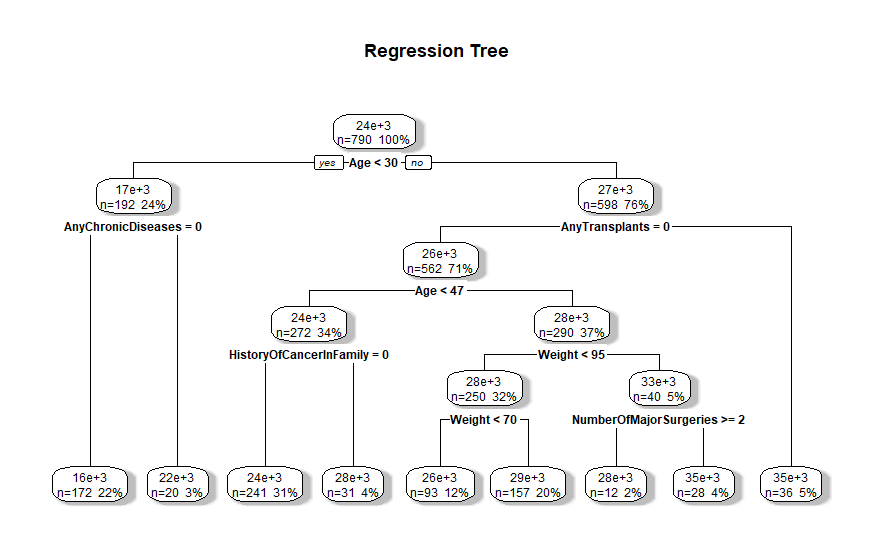

```r
## Determine the minimum complexity parameter (cp) for pruning
best_cp <- model_tree$cptable[which.min(model_tree$cptable[,"xerror"]), "CP"]

# Prune the regression tree model using the best cp
pruned_tree <- prune(model_tree, cp = best_cp)
prp(pruned_tree,
    type = 2,           # show variable names in splits
    extra = 101,        # show RMSE and samples in leaves
    fallen.leaves = TRUE,
    faclen = 0,         # do not abbreviate factor levels
    varlen = 0,         # do not abbreviate variable names
    shadow.col = "gray",   # Add shadow
    main = "Regression Tree")
```

As we can see the *pruned_tree* is exactly the same with the *model_tree*. It means that *model_tree* is already using that exact CP internally.

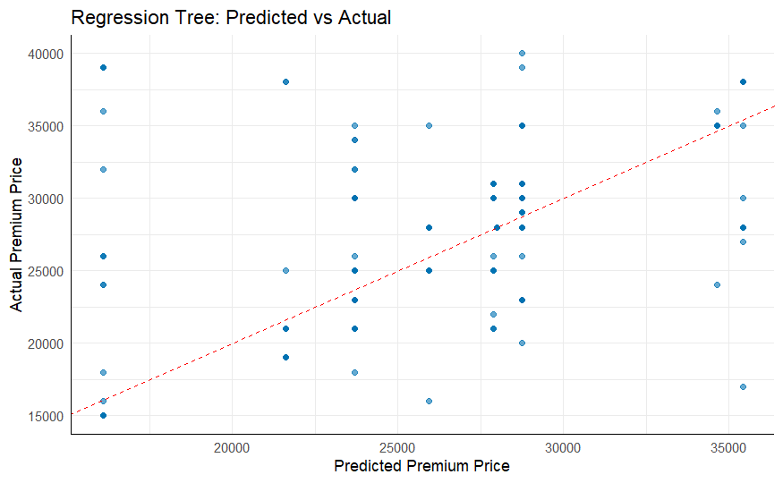

```r
library(ggplot2)

# Predict on training data
tree_pred <- predict(model_tree, train)

# Create a data frame for plotting
df_plot <- data.frame(
  Predicted = tree_pred,
  Actual = train$PremiumPrice
)

# Plot using ggplot2
ggplot(df_plot, aes(x = Predicted, y = Actual)) +
  geom_point(color = "#0072B2", alpha = 0.6) +
  geom_abline(slope = 1, intercept = 0, linetype = "dashed", color = "red") +
  labs(
    x = "Predicted Premium Price",
    y = "Actual Premium Price",
    title = "Regression Tree: Predicted vs Actual"
  ) +
  theme_minimal() +
  theme(axis.line = element_line(color = "#000000"))
```

While the predictions generally follow the upward trend of the red “perfect prediction” line, the stepped nature and the scatter indicate the tree captures broad patterns but doesn’t perfectly predict each individual price.

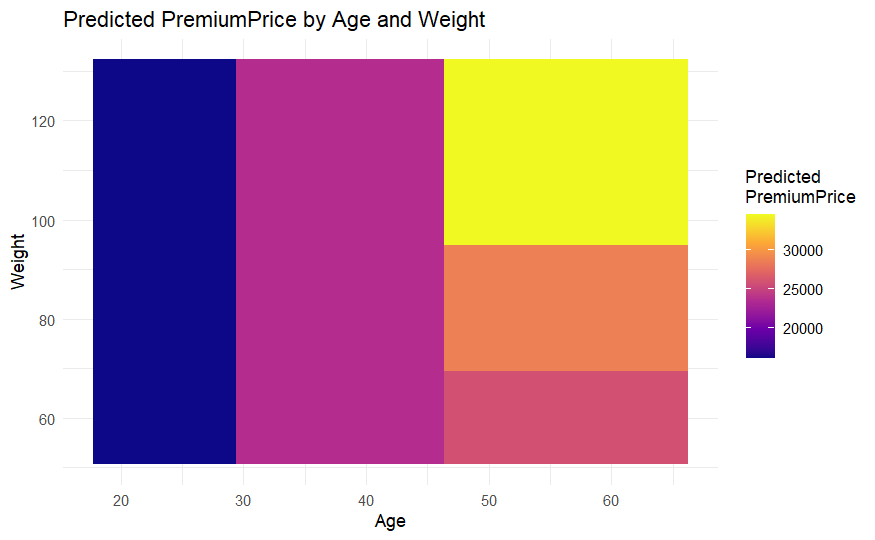

```r
library(ggplot2)
library(dplyr)

# Create a grid of Age and Weight values to make predictions on
age_range <- seq(min(train$Age), max(train$Age), length.out = 100)
weight_range <- seq(min(train$Weight), max(train$Weight), length.out = 100)

grid <- expand.grid(
  Age = age_range,
  Weight = weight_range
)

# Get median for numeric columns only
numeric_vars <- train %>%
  select(-PremiumPrice, -Age, -Weight) %>%
  select(where(is.numeric)) %>%
  summarise(across(everything(), ~ median(., na.rm = TRUE))) %>%
  slice(rep(1, nrow(grid)))

# For non-numeric variables (factors, logicals), pick the most frequent level
non_numeric_vars <- train %>%
  select(-PremiumPrice, -Age, -Weight) %>%
  select(where(Negate(is.numeric))) %>%
  summarise(across(everything(), ~ as.character(names(sort(table(.), decreasing = TRUE)[1])))) %>%
  slice(rep(1, nrow(grid)))

# Combine grid with typical values
predict_data <- bind_cols(grid, numeric_vars, non_numeric_vars)

# Predict PremiumPrice using the regression tree model
grid$Predicted <- predict(model_tree, newdata = predict_data)

# Plot contour heatmap
ggplot(grid, aes(x = Age, y = Weight, fill = Predicted)) +
  geom_tile() +
  scale_fill_viridis_c(option = "plasma") +
  labs(
    title = "Predicted PremiumPrice by Age and Weight",
    x = "Age",
    y = "Weight",
    fill = "Predicted\nPremiumPrice"
  ) +
  theme_minimal()
```

```r
#Training RMSE
library(Metrics)
train_rmse_tree <- rmse(train$PremiumPrice, tree_pred)

# Extract minimum cross-validation error (xerror)
min_xerror <- min(model_tree$cptable[,"xerror"])
root_node_error <- model_tree$cptable[1, "rel error"]

# Convert xerror (relative) into actual RMSE estimate:
cv_rmse_tree <- sqrt(min_xerror * model_tree$frame$dev[1] / nrow(train))
```

## Comparison

```r
library(knitr)

# Create the same data frame
model_comparison <- data.frame(
  Model = c("Linear Model", "Regression Tree"),
  Training_RMSE = c(round(lm_train_rmse, 2), round(train_rmse_tree, 2)),
  CV_RMSE = c(round(mean(pred_lm_cv_rmse), 2), round(cv_rmse_tree, 2))
)

# Print nicely formatted table
kable(model_comparison, caption = "Comparison of Training and CV RMSE for Both Models")
```

Comparison of Training and CV RMSE for Both Models

| Model | Training_RMSE | CV_RMSE |
| --- | --- | --- |
| Linear Model | 3847.17 | 3881.83 |
| Regression Tree | 3224.39 | 3379.69 |

RMSE(Root Mean Squared Error) is in the same units as the target variable, making it easier to interpret. **Training RMSE** measures the average prediction error on the data the model was trained on. **CV RMSE** measures the model’s ability to generalize, based on cross-validation (i.e., how well it would perform on unseen data).

The *Regression Tree* has both lower training and CV RMSE, which means: It fits the training data more closely. It also generalizes better to unseen data, as shown by lower CV RMSE.

# Ensemble Methods

## Bagging

### (Random Forest)

```r
library(randomForest)  # For Random Forest modeling
library(caret)         # For training and cross-validation
library(dplyr)         # For data manipulation
library(tibble)        # For cleaner result tables

# Use the same training data as for the regression tree
train_rf <- train

#ntree: number of trees to grow in the forest

# Define grid of hyperparameters to tune:
# - mtry: number of variables randomly sampled at each split
tune_grid <- expand.grid(mtry = c(2, 4, 6, 8))

# Set up 5-fold cross-validation
control <- trainControl(method = "cv", number = 5)

# Train Random Forest model using caret::train
# This performs grid search over the tuning grid and evaluates RMSE for each
set.seed(123)
rf_tuned <- train(
  PremiumPrice ~ .,         # Target variable is PremiumPrice
  data = train_rf,          # Use the training data
  method = "rf",            # Random Forest
  metric = "RMSE",          # Use RMSE as evaluation metric
  tuneGrid = tune_grid,     # Provide the tuning grid
  trControl = control       # Provide the CV setup
)

# Display results of tuning
print(rf_tuned)     # Best hyperparameters + their RMSE
```

```
Random Forest

790 samples
 10 predictor

No pre-processing
Resampling: Cross-Validated (5 fold)
Summary of sample sizes: 632, 632, 631, 632, 633
Resampling results across tuning parameters:

  mtry  RMSE      Rsquared   MAE
  2     3587.889  0.7202763  2454.071
  4     3130.676  0.7569366  1674.153
  6     3071.268  0.7637242  1452.491
  8     3091.841  0.7602777  1356.663

RMSE was used to select the optimal model using the smallest value.
The final value used for the model was mtry = 6.
```

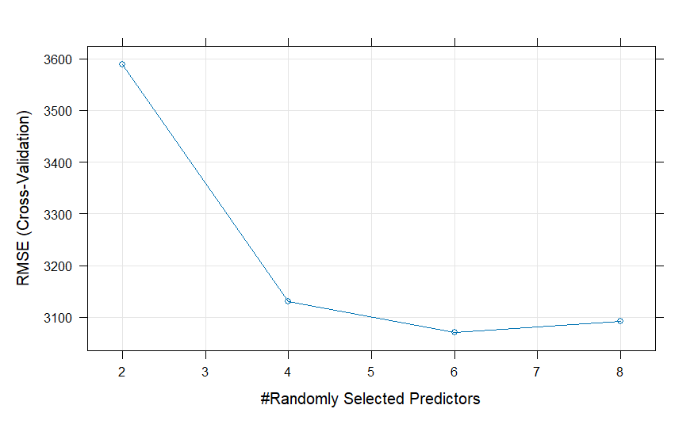

```r
plot(rf_tuned)      # Visual plot of tuning results
```

We tested four different values of *mtry* (number of variables considered at each split): 2, 4, 6, and 8. As can be seen,among all Cross-Validation RMSEs, the best CV-RMSE is for *mtry* = 6, because it has the lowest CV-RMSE (3071.268).

```r
# using the trained Random Forest model (rf_tuned).
# The model rf_tuned already contains the best hyperparameters found by caret,
# including mtry = 6, which was selected based on the lowest cross-validation RMSE.
train_pred_rf <- predict(rf_tuned, newdata = train_rf)

# Calculate (RMSE) on the final model (with mtry = 6) fits the training data.
train_rmse_rf <- RMSE(train_pred_rf, train_rf$PremiumPrice)


# Get best CV RMSE from caret tuning results
cv_rmse_rf <- min(rf_tuned$results$RMSE)

# Create a summary table to report RMSE values
result_table <- tibble(
  Model = "Random Forest",
  Training_RMSE = train_rmse_rf,
  CV_RMSE = cv_rmse_rf
)

# Print the results
print(result_table)
```

| Model | Training_RMSE | CV_RMSE |
| --- | --- | --- |
| Random Forest | 1588.918 | 3071.268 |

After training the final model using this best configuration, we evaluated its performance on the training data. The training RMSE was 1588.918, which is considerably lower than the CV RMSE, suggesting some degree of overfitting. However, the model still generalizes reasonably well, as indicated by the CV RMSE. These results demonstrate that tuning *mtry* has a significant impact on performance, and it’s important to assess both training and cross-validation loss to understand the model’s ability to generalize.

## Boosting

### GBM (Gradient Boosting Machine)

```r
library(caret)
library(gbm)

# Define a custom tuning grid with multiple hyperparameters
gbm_grid <- expand.grid(
  interaction.depth = 1:5,                  # Max depth of each tree
  n.trees = c(500, 1000, 2000, 5000),       # Number of boosting iterations (trees)
  shrinkage = c(0.1, 0.01, 0.001),          # Learning rate (smaller = slower learning, more trees needed)
  n.minobsinnode = c(10, 20)                # Minimum number of observations in terminal nodes
)

# Cross-validation settings
train_settings <- trainControl(method = "cv", number = 5)

# Train GBM model with the defined grid and CV
caret_gbm <- train(
  PremiumPrice ~ .,
  data = train,
  method = "gbm",                # GBM model method
  trControl = train_settings,
  tuneGrid = gbm_grid,
  verbose = FALSE                # Suppress verbose output from gbm
)

# Show only first few results (summary)
head(caret_gbm$results)
```

|  | shrinkage | interaction.depth | n.minobsinnode | n.trees | RMSE | Rsquared | MAE | RMSESD | RsquaredSD | MAESD |
| --- | --- | --- | --- | --- | --- | --- | --- | --- | --- | --- |
| 1 | 0.001 | 1 | 10 | 500 | 5230.668 | 0.5273937 | 4182.782 | 359.6339 | 0.08688679 | 208.1851 |
| 5 | 0.001 | 1 | 20 | 500 | 5232.735 | 0.5276208 | 4184.544 | 356.5027 | 0.08808825 | 208.1240 |
| 41 | 0.010 | 1 | 10 | 500 | 3665.742 | 0.6767910 | 2531.772 | 583.4492 | 0.09764434 | 198.4139 |
| 45 | 0.010 | 1 | 20 | 500 | 3695.748 | 0.6729289 | 2552.726 | 581.9358 | 0.09625116 | 203.1236 |
| 81 | 0.100 | 1 | 10 | 500 | 3557.082 | 0.6851737 | 2307.985 | 661.6872 | 0.09892005 | 212.3517 |
| 85 | 0.100 | 1 | 20 | 500 | 3562.773 | 0.6851069 | 2318.199 | 665.4419 | 0.10176324 | 200.6761 |

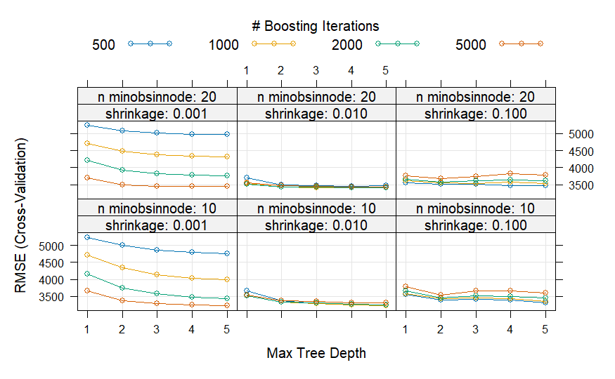

```r
plot(caret_gbm)
```

We used cross-validated RMSE to investigate different hyperparameter combinations for the Gradient Boosting model. From the tuning results, we observed that:

- Smaller *shrinkage* values (like 0.001) led to much higher RMSE, indicating underfitting.
- Increasing tree depth *(interaction.depth)* generally improved performance up to a point, after which gains leveled off.
- Using 10 observations per node gave better performance than 20.
- Based on the first few rows, for example, a relatively low RMSE (~3557) was observed with *shrinkage = 0.1*, *interaction.depth = 1*, and *n.minobsinnode = 10*.

```r
library(caret)
library(dplyr)
library(tibble)
library(gbm)

# Predict on the training data using the final (best) GBM model
train_pred_gbm <- predict(caret_gbm, newdata = train)

# Calculate Training RMSE of the best model
train_rmse_gbm <- RMSE(train_pred_gbm, train$PremiumPrice)

# Get the best CV RMSE from the tuning results
cv_rmse_gbm <- min(caret_gbm$results$RMSE)

caret_gbm$bestTune
```

|  | n.trees | interaction.depth | shrinkage | n.minobsinnode |
| --- | --- | --- | --- | --- |
| 73 | 500 | 5 | 0.01 | 10 |

```r
# Create a summary table to display results
result_table_gbm <- tibble(
  Model = "Gradient Boosting",
  Training_RMSE = train_rmse_gbm,
  CV_RMSE = cv_rmse_gbm
)
print(result_table_gbm)
```

| Model | Training_RMSE | CV_RMSE |
| --- | --- | --- |
| Gradient Boosting | 2853.152 | 3223.956 |

The Gradient Boosting model was evaluated using RMSE (Root Mean Squared Error), a standard metric for regression problems that measures the average magnitude of prediction errors in the same unit as the target variable (₹ in this case).

Training RMSE: 2853.15 This indicates how well the model fits the training data. A lower value means the model can predict the premium prices accurately on the data it was trained on.

Cross-Validation (CV) RMSE: 3223.96 This estimates the model’s performance on unseen data using 5-fold cross-validation. It reflects how well the model is expected to generalize to new data.

The fact that the CV RMSE is only moderately higher than the training RMSE suggests that: The model fits the training data well. There is no major overfitting (i.e., the model’s good performance is not limited only to training data). The GBM model appears to generalize reasonably well.

## Ensemble methods comparison and best Configurations

Both ensemble models — Random Forest (RF) and Gradient Boosting Machine (GBM) — were trained and evaluated using 5-fold cross-validation, with Root Mean Squared Error (RMSE) as the consistent evaluation metric. The Random Forest model achieved a **Training RMSE of 1588.92** and a **CV RMSE of 3071.27**, while the GBM model produced a **Training RMSE of 2853.15** and a **CV RMSE of 3223.96**. Based on the lower CV RMSE, Random Forest outperformed GBM in terms of generalization to unseen data.

The best hyperparameter configuration for Random Forest was found to be **mtry = 6**, which controls the number of predictors randomly selected at each tree split. For GBM, the best performance was obtained using **interaction.depth = 5**, **n.trees = 500**, **shrinkage = 0.01**, and **n.minobsinnode = 10**. These configurations were selected based on the minimum RMSE values observed during cross-validation tuning.

In conclusion, **the Random Forest model** with mtry = 6 was selected as the best-performing ensemble model due to its superior cross-validation performance, indicating stronger predictive capability and better generalization for modeling insurance premium prices.

# Neural Networks

```r
# Remove target variable from X
X_raw <- data[, setdiff(names(data), "PremiumPrice")]

# Convert all columns in X to numeric
X <- as.matrix(data.frame(lapply(X_raw, function(col) as.numeric(as.character(col)))))

# Convert target to numeric matrix
y <- as.matrix(data$PremiumPrice)

# Normalize the input features using a Keras normalization layer
library(keras3)                         # Without normalization:Features on larger scales dominate learning
normalize <- layer_normalization()      # Create normalization layer
normalize %>% adapt(data = X)           # Compute mean & variance from data and store it inside the layer


print(normalize$mean)
```

```
tf.Tensor(
[[4.1745438e+01 4.1987830e-01 4.6855983e-01 5.5780932e-02 1.8052739e-01
  1.6818256e+02 7.6950302e+01 2.1501014e-01 1.1764706e-01 6.6734278e-01]], shape=(1, 10), dtype=float32)
```

```r
print(normalize$variance)  # Variance of features
```

```
tf.Tensor(
[[1.94777847e+02 2.43582457e-01 2.49009296e-01 5.26695922e-02
  1.47938117e-01 1.01869286e+02 2.03286514e+02 1.68781117e-01
  1.03805706e-01 5.60736954e-01]], shape=(1, 10), dtype=float32)
```

```r
library(keras3)
# 1. Define the architecture: sequential model
model <- keras_model_sequential()

# 2. Add layers step by step
model %>%

  # Layer 1: Normalization (standardizes inputs, we adapted it earlier)
  normalize %>%

  # Layer 2: Hidden layer with 8 neurons and ReLU activation
  layer_dense(
    name = "HiddenLayer",   # Optional name for layer
    units = 8,              # Number of neurons, a starting point
    activation = "relu"     # ReLU is good for most hidden layers
  ) %>%                    # Keeps positive signals, zeroes out negative ones. Helps train deep models effectively

  # Layer 3: Output layer with 1 neuron for numeric prediction
  layer_dense(
    name = "OutputLayer",     # Optional name
    units = 1                 # One output = predicted PremiumPrice
    # No activation = linear by default (good for regression)
  )

# 3. Inspect the model structure
summary(model)
```

```
Model: "sequential"
┌────────────────────────────────────────────────┬─────────────────────────────────────┬──────────────────────
│ Layer (type)                                   │ Output Shape                        │              Param #
├────────────────────────────────────────────────┼─────────────────────────────────────┼──────────────────────
│ normalization_1 (Normalization)                │ (986, 10)                           │                   21
├────────────────────────────────────────────────┼─────────────────────────────────────┼──────────────────────
│ HiddenLayer (Dense)                            │ ?                                   │          0 (unbuilt)
├────────────────────────────────────────────────┼─────────────────────────────────────┼──────────────────────
│ OutputLayer (Dense)                            │ ?                                   │          0 (unbuilt)
└────────────────────────────────────────────────┴─────────────────────────────────────┴──────────────────────
 Total params: 21 (88.00 B)
 Trainable params: 0 (0.00 B)
 Non-trainable params: 21 (88.00 B)
```

986 rows (observations) and 10 features (columns). The normalization layer: stores mean (10 features) → 10 params, stores variance (10 features) → 10 params, Plus 1 bias-like term (often added internally by Keras) → 1 param Total: 10 + 10 + 1 = 21 parameters, all of which are not trainable. HiddenLayer and OutputLayer show 0 (unbuilt) — this just means the model hasn’t been compiled and trained yet, so it hasn’t figured out how many parameters it will train.

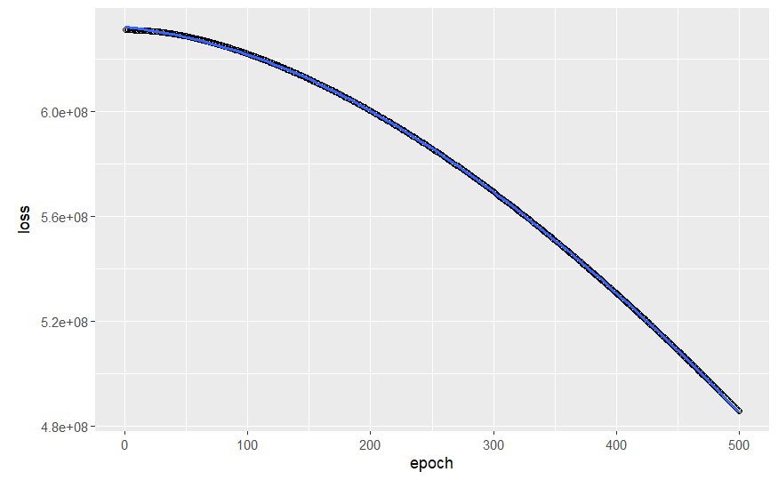

```r
library(keras3)

# Compile the model: define how it should learn
model %>% compile(
  loss = "mse",         # Use Mean Squared Error (MSE) for regression
  optimizer = "adam"    # Use the Adam optimizer (advanced gradient descent)
)

# Train (fit) the model using the data
model_nn <- model %>% fit(
  x = X,                # input features (10 columns)
  y = y,                # target: PremiumPrice
  epochs = 500,         # Repeats learning 500 times to improve performance
  verbose = 0           # 0 means silent; set to 1 to see progress
)

plot(model_nn)
```

```r
library(Metrics)  # for RMSE function
library(lattice)
# Predict on training data
y_pred_train <- predict(model, X)
```

```
 1/31 ━━━━━━━━━━━━━━━━━━━━ 5s 173ms/step
14/31 ━━━━━━━━━━━━━━━━━━━━ 0s 4ms/step
31/31 ━━━━━━━━━━━━━━━━━━━━ 0s 5ms/step
31/31 ━━━━━━━━━━━━━━━━━━━━ 0s 7ms/step
```

```r
# Calculate RMSE on training data
rmse_train <- rmse(actual = y, predicted = y_pred_train)

library(keras3)
library(tidyverse)  # for data manipulation
library(caret)      # for creating folds
set.seed(123)
# Create 5 folds (subsets) of the data for cross-validation
# y is the target variable
# Each fold will be used once as a validation set, the rest as training data
folds <- createFolds(y, k = 5, list = TRUE, returnTrain = FALSE)

cv_rmse <- c()  # to store RMSEs from each fold

# Start a loop over the 5 folds for manual cross-validation
for (i in 1:5) {

  cat("Running Fold", i, "\n")   # Print the current fold number being processed

  # Get the indices of the current fold to be used as validation data
  val_indices <- folds[[i]]
  # Create training set by removing the validation fold from the full dataset
  X_train <- X[-val_indices, , drop = FALSE]   # Drop FALSE keeps matrix structure
  y_train <- y[-val_indices, , drop = FALSE]
  # Create validation set using only the indices of the current fold
  X_val <- X[val_indices, , drop = FALSE]
  y_val <- y[val_indices, , drop = FALSE]

  # Normalize on training data
  normalize <- layer_normalization()
  normalize %>% adapt(X_train)

  # Build model (same architecture as before)
  model_cv <- keras_model_sequential() %>%
    normalize() %>%
    layer_dense(units = 8, activation = "relu", name = "HiddenLayer") %>%
    layer_dense(units = 1, name = "OutputLayer")

  # Compile
  model_cv %>% compile(
    loss = "mse",
    optimizer = "adam"
  )

  # Fit
  model_cv %>% fit(
    x = X_train,
    y = y_train,
    epochs = 500,
    verbose = 0
  )

  # Predict on validation set
  y_pred_val <- predict(model_cv, X_val)

  # Compute RMSE
  fold_rmse <- rmse(y_val, y_pred_val)
  cv_rmse <- c(cv_rmse, fold_rmse)
}
```

[output not shown]

```r
mean_cv_rmse <- mean(cv_rmse)
print(paste("Average CV RMSE:", round(mean_cv_rmse, 2)))
```

```
[1] "Average CV RMSE: 23211.1"
```

```r
print(rmse_train)
```

```
[1] 22034.11
```

We trained a neural network model using one hidden layer with 8 ReLU neurons. The model achieved a Training RMSE of approximately 22034.11 and a Cross-Validation RMSE of approximately 23211.1.

### Configuration 2: More Neurons(32 neurons)

```r
library(keras3)
library(tidyverse)
library(caret)
library(Metrics)

# Define the normalization layer
normalize_layer <- layer_normalization()
normalize_layer %>% adapt(X)

# Build the model
model2 <- keras_model_sequential() %>%
  normalize_layer %>%                                # Preprocessing: normalize input
  layer_dense(units = 32, activation = "relu",        # Hidden layer with 32 neurons
              name = "HiddenLayer") %>%
  layer_dense(units = 1, name = "OutputLayer")        # Output layer

# Compile the model
model2 %>% compile(
  loss = "mse",
  optimizer = "adam"
)

# train the model
model_nn2 <- model2 %>% fit(
  x = X,
  y = y,
  epochs = 500,
  verbose = 0
)

# Evaluate model2
train_pred2 <- model2 %>% predict(X)
```

```
 1/31 ━━━━━━━━━━━━━━━━━━━━ 3s 120ms/step
31/31 ━━━━━━━━━━━━━━━━━━━━ 0s 3ms/step
31/31 ━━━━━━━━━━━━━━━━━━━━ 0s 4ms/step
```

```r
rmse_train2 <- sqrt(mean((train_pred2 - y)^2))

# 5-fold CV RMSE
folds <- cut(seq(1, nrow(X)), breaks = 5, labels = FALSE)
cv_rmse2 <- c()
for(i in 1:5){
  test_idx <- which(folds == i)
  X_train <- X[-test_idx,]
  y_train <- y[-test_idx,]
  X_test <- X[test_idx,]
  y_test <- y[test_idx,]

  # Create and train the model again on this fold
  model_cv <- keras_model_sequential() %>%
    normalize_layer %>%
    layer_dense(units = 32, activation = "relu") %>%
    layer_dense(units = 1)

  model_cv %>% compile(
    loss = "mse",
    optimizer = "adam"
  )

  model_cv %>% fit(x = X_train, y = y_train, epochs = 500, verbose = 0)

  preds <- model_cv %>% predict(X_test)
  rmse <- sqrt(mean((preds - y_test)^2))
  cv_rmse2 <- c(cv_rmse2, rmse)
}
```

```
1/7 ━━━━━━━━━━━━━━━━━━━━ 0s 66ms/step
7/7 ━━━━━━━━━━━━━━━━━━━━ 0s 11ms/step
7/7 ━━━━━━━━━━━━━━━━━━━━ 0s 17ms/step
```

```
G2;H2;WARNINGh:tensorflow:5 out of the last 39 calls to <function TensorFlowTrainer.make_predict_function.<locals>.one_step_on_data_distributed at 0x0000023988D725F0> triggered tf.function retracing. Tracing is expensive and the excessive number of tracings could be due to (1) creating @tf.function …
g
```

```
1/7 ━━━━━━━━━━━━━━━━━━━━ 0s 69ms/step
7/7 ━━━━━━━━━━━━━━━━━━━━ 0s 22ms/step
7/7 ━━━━━━━━━━━━━━━━━━━━ 0s 29ms/step
```

```
G2;H2;WARNINGh:tensorflow:5 out of the last 15 calls to <function TensorFlowTrainer.make_predict_function.<locals>.one_step_on_data_distributed at 0x0000023988F22C20> triggered tf.function retracing. Tracing is expensive and the excessive number of tracings could be due to (1) creating @tf.function …
g
```

```
1/7 ━━━━━━━━━━━━━━━━━━━━ 0s 70ms/step
7/7 ━━━━━━━━━━━━━━━━━━━━ 0s 11ms/step
7/7 ━━━━━━━━━━━━━━━━━━━━ 0s 16ms/step

1/7 ━━━━━━━━━━━━━━━━━━━━ 0s 67ms/step
7/7 ━━━━━━━━━━━━━━━━━━━━ 0s 11ms/step
7/7 ━━━━━━━━━━━━━━━━━━━━ 0s 16ms/step

1/7 ━━━━━━━━━━━━━━━━━━━━ 0s 68ms/step
7/7 ━━━━━━━━━━━━━━━━━━━━ 0s 11ms/step
7/7 ━━━━━━━━━━━━━━━━━━━━ 0s 16ms/step
```

```r
mean(cv_rmse2)  # CV RMSE for configuration 2
```

```
[1] 18340.03
```

### Configuration 3: Two Hidden Layers

```r
# Define normalization layer
normalize_layer <- layer_normalization()
normalize_layer %>% adapt(X)

# Build the Neural Network with two hidden layers
model3 <- keras_model_sequential()

model3 %>%
  normalize_layer %>%                              # Layer 1: Normalize input features
  layer_dense(units = 16, activation = "relu",     # Layer 2: First hidden layer with 16 neurons
              name = "HiddenLayer1") %>%
  layer_dense(units = 8, activation = "relu",      # Layer 3: Second hidden layer with 8 neurons
              name = "HiddenLayer2") %>%
  layer_dense(units = 1, name = "OutputLayer")     # Layer 4: Output layer for regression

# Compile the model
model3 %>% compile(
  loss = "mse",           # Loss function: Mean Squared Error for regression
  optimizer = "adam"      # Optimizer: Adam (efficient gradient descent)
)

# Train the model
model_nn3 <- model3 %>% fit(
  x = X,
  y = y,
  epochs = 500,           # Number of training epochs
  verbose = 0             # Suppress output while training
)

# Predict on training data
train_pred3 <- model3 %>% predict(X)
```

```
 1/31 ━━━━━━━━━━━━━━━━━━━━ 4s 140ms/step
21/31 ━━━━━━━━━━━━━━━━━━━━ 0s 3ms/step
31/31 ━━━━━━━━━━━━━━━━━━━━ 0s 5ms/step
31/31 ━━━━━━━━━━━━━━━━━━━━ 0s 6ms/step
```

```r
# Calculate Training RMSE
rmse_train3 <- sqrt(mean((train_pred3 - y)^2))
cat("Training RMSE (2 hidden layers):", round(rmse_train3, 2), "\n")
```

```
Training RMSE (2 hidden layers): 3733.3
```

```r
# perform 5-Fold Cross-Validation
set.seed(123)
folds <- cut(seq(1, nrow(X)), breaks = 5, labels = FALSE)
cv_rmse3 <- c()

for (i in 1:5) {
  # Split data
  test_idx <- which(folds == i)
  X_train <- X[-test_idx, ]
  y_train <- y[-test_idx, ]
  X_test <- X[test_idx, ]
  y_test <- y[test_idx, ]

  # Build model again with same architecture
  model_cv <- keras_model_sequential() %>%
    normalize_layer %>%
    layer_dense(units = 16, activation = "relu") %>%
    layer_dense(units = 8, activation = "relu") %>%
    layer_dense(units = 1)

  model_cv %>% compile(
    loss = "mse",
    optimizer = "adam"
  )

  model_cv %>% fit(x = X_train, y = y_train, epochs = 500, verbose = 0)

  # Predict and calculate RMSE for this fold
  preds <- model_cv %>% predict(X_test)
  rmse <- sqrt(mean((preds - y_test)^2))
  cv_rmse3 <- c(cv_rmse3, rmse)
}
```

```
1/7 ━━━━━━━━━━━━━━━━━━━━ 0s 77ms/step
7/7 ━━━━━━━━━━━━━━━━━━━━ 0s 13ms/step
7/7 ━━━━━━━━━━━━━━━━━━━━ 0s 19ms/step

1/7 ━━━━━━━━━━━━━━━━━━━━ 0s 77ms/step
7/7 ━━━━━━━━━━━━━━━━━━━━ 0s 14ms/step
7/7 ━━━━━━━━━━━━━━━━━━━━ 0s 20ms/step

1/7 ━━━━━━━━━━━━━━━━━━━━ 0s 76ms/step
7/7 ━━━━━━━━━━━━━━━━━━━━ 0s 22ms/step
7/7 ━━━━━━━━━━━━━━━━━━━━ 0s 29ms/step

1/7 ━━━━━━━━━━━━━━━━━━━━ 0s 78ms/step
7/7 ━━━━━━━━━━━━━━━━━━━━ 0s 14ms/step
7/7 ━━━━━━━━━━━━━━━━━━━━ 0s 20ms/step

1/7 ━━━━━━━━━━━━━━━━━━━━ 0s 80ms/step
7/7 ━━━━━━━━━━━━━━━━━━━━ 0s 14ms/step
7/7 ━━━━━━━━━━━━━━━━━━━━ 0s 20ms/step
```

```r
# Calculate average CV RMSE
mean_cv_rmse3 <- mean(cv_rmse3)
cat("Average CV RMSE (2 hidden layers):", round(mean_cv_rmse3, 2), "\n")
```

```
Average CV RMSE (2 hidden layers): 4008.88
```

### Comparison Neural Network Configurations

```r
# Create a data frame with results of all 3 configurations
nn_results <- data.frame(
  Configuration = c("1 Hidden Layer (8 neurons)",
                    "1 Hidden Layer (32 neurons)",
                    "2 Hidden Layers (16 + 8 neurons)"),
  Train_RMSE = c(22034.11 , 13164.1, 3733.3),
  CV_RMSE = c(23211.11, 18340.03, 4008.88)
)

print(nn_results)
```

| Configuration | Train_RMSE | CV_RMSE |
| --- | --- | --- |
| 1 Hidden Layer (8 neurons) | 22034.11 | 23211.11 |
| 1 Hidden Layer (32 neurons) | 13164.10 | 18340.03 |
| 2 Hidden Layers (16 + 8 neurons) | 3733.30 | 4008.88 |

Among the three neural network configurations tested, Configuration 3 **(two hidden layers)** achieved the best performance with a Training RMSE of 3733.3 and a CV RMSE of 4008.88. This configuration significantly outperformed the single-layer (Configuration 1: CV RMSE ~23211) and the wide-layer model (Configuration 2: CV RMSE ~18,340). Therefore, **Configuration 3 is selected as the best based on the RMSE evaluation metric**.

# Model Comparison

```r
# Create a summary data frame
model_comparison <- data.frame(
  Model = c("Linear Model",
            "Regression Tree",
            "Random Forest",
            "Gradient Boosting (GBM)",
            "Neural Network (2 Hidden Layers)"),
  Training_RMSE = c(3847.17, 3224.39, 1588.92, 2853.15, 3733.3),
  CV_RMSE = c(3881.83, 3379.69, 3071.27, 3223.96, 4008.88)
)

print(model_comparison)
```

| Model | Training_RMSE | CV_RMSE |
| --- | --- | --- |
| Linear Model | 3847.17 | 3881.83 |
| Regression Tree | 3224.39 | 3379.69 |
| Random Forest | 1588.92 | 3071.27 |
| Gradient Boosting (GBM) | 2853.15 | 3223.96 |
| Neural Network (2 Hidden Layers) | 3733.30 | 4008.88 |

I evaluated and compared five models using Root Mean Squared Error (RMSE) as the consistent evaluation metric for both training and cross-validation (CV) performance:

- **Random Forest** achieved the **lowest Training RMSE (1588.92) and the lowest CV RMSE (3071.27)** among all models. This suggests it fit the training data well and also generalized best to unseen data.
- Regression Tree and GBM models followed, with CV RMSEs around 3200–3400, indicating decent performance but not as strong as Random Forest.
- The Linear Model showed relatively higher RMSEs, implying underfitting due to its simplicity.
- The Neural Network with two hidden layers had the highest CV RMSE (4008.88), meaning it did not generalize as well in this case — possibly due to overfitting or needing more tuning/data.

# PCA

```r
# Standardize the input variables

# Standardize the already numeric input matrix (X)
X_scaled <- scale(X)   # Standardizes each column to mean 0 and standard deviation 1.

# Run PCA using prcomp
model_pca <- prcomp(X_scaled) #computes principal components from the covariance matrix of the scaled data.


summary(model_pca)
```

```
Importance of components:
                         PC1    PC2    PC3    PC4    PC5    PC6    PC7     PC8     PC9    PC10
Standard deviation     1.323 1.1130 1.0443 1.0398 1.0010 0.9492 0.9370 0.88862 0.87628 0.70793
Proportion of Variance 0.175 0.1239 0.1090 0.1081 0.1002 0.0901 0.0878 0.07896 0.07679 0.05012
Cumulative Proportion  0.175 0.2989 0.4079 0.5160 0.6162 0.7063 0.7941 0.87310 0.94988 1.00000
```

PC1 alone explains 17.5% of the total variance. First 3 PCs together explain about 41% of total variance. First 5 PCs explain ~61.6%

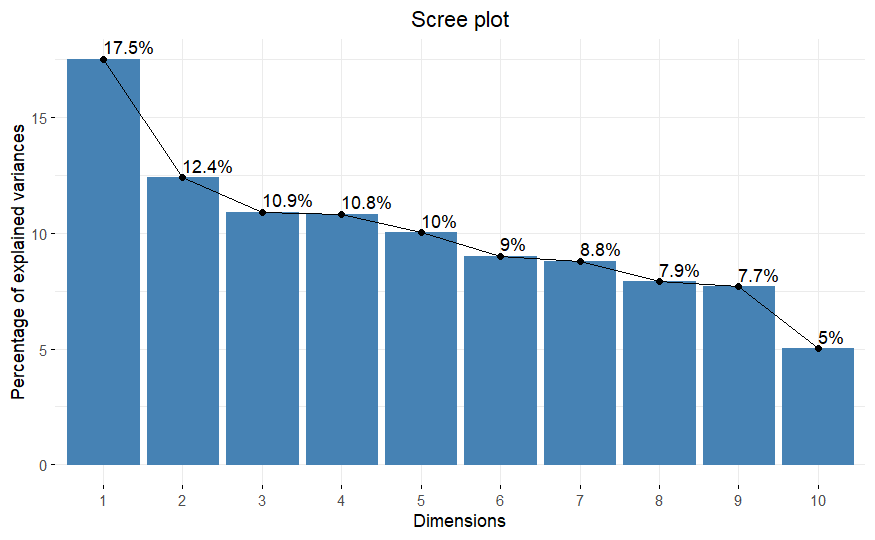

```r
# visualize the importance of each principal component
library(factoextra)

# Plot the variance explained by each principal component
fviz_eig(model_pca,                # PCA model object
         addlabels = TRUE          # Show exact values on the bars
) +
  theme(plot.title = element_text(hjust = 0.5))  # Center the plot title
```

From the plot we see that we can explain ~80-90% of the variance with 7-8 PCs.

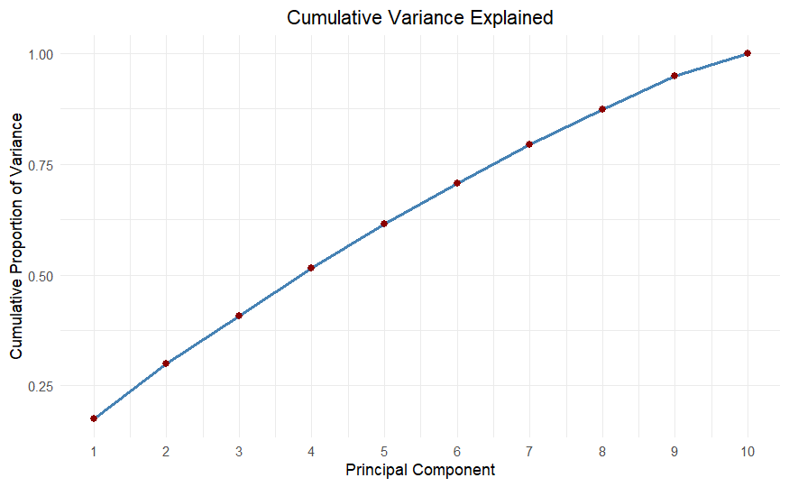

```r
# visualizing the cumulative variance explained by the principal components
library(data.table)  # For efficient data manipulation
library(ggplot2)

# Create a data table with the variance explained by each PC
df_cumsum <- data.table(
  Var = model_pca$sdev^2 / sum(model_pca$sdev^2),  # Proportion of variance for each PC
  PC = 1:length(model_pca$sdev)                    # PC index: PC1, PC2, ...
)

# Plot cumulative variance explained
ggplot(data = df_cumsum, aes(x = PC, y = cumsum(Var))) +
  geom_line(color = "steelblue", size = 1) +        # Line plot of cumulative variance
  geom_point(color = "darkred", size = 2) +         # Points on the line
  labs(
    title = "Cumulative Variance Explained",
    x = "Principal Component",
    y = "Cumulative Proportion of Variance"
  ) +
  scale_x_continuous(breaks = 1:nrow(df_cumsum)) +  # Show all PCs on x-axis
  theme_minimal() +
  theme(
    plot.title = element_text(hjust = 0.5),         # Center the title
    axis.line = element_blank()
  )
```

The cumulative variance plot shows that the first 6 principal components explain just over 70% of the total variance in the input variables. Including up to 8 PCs increases this to ~88%

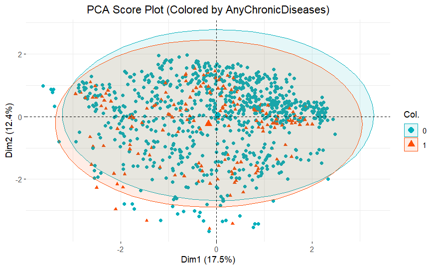

```r
library(factoextra)
library(ggplot2)


# Choose a variable to color by: let's use "AnyChronicDiseases"
# It must be a factor for coloring
color_var <- as.factor(data$AnyChronicDiseases)

# Create a score plot using the first two principal components (PC1 and PC2)
fviz_pca_ind(model_pca,
             geom.ind = "point",                    # Show data points
             col.ind = color_var,                  # Color by AnyChronicDiseases (0/1)
             palette = c("#00AFBB", "#FC4E07"),    # Nice contrasting colors
             addEllipses = TRUE                    # Optional: adds grouping ellipses
             ) +
  ggtitle("PCA Score Plot (Colored by AnyChronicDiseases)") +
  theme(plot.title = element_text(hjust = 0.5))
```

Each point represents one person (data row) in the reduced 2D space (PC1 and PC2). AnyChronicDiseases: Blue circles = 0 (no chronic disease) Red triangles = 1 (has chronic disease) Ellipses summarize the overall “cloud” of each group, indicating concentration and spread. The axes represent the first two principal components: Dim1 (dimension,PC1) explains 17.5% of variance. Dim2 (PC2) explains 12.4%. There is a lot of overlap between the two groups. The red and blue ellipses are nearly on top of each other. This tells us that the first two PCs do not clearly separate people with chronic diseases from those without. This suggests that the first two PCs do not distinguish well between these groups. As PCA is an unsupervised technique, this is expected(it’s not designed to classify, just to summarize variance.)

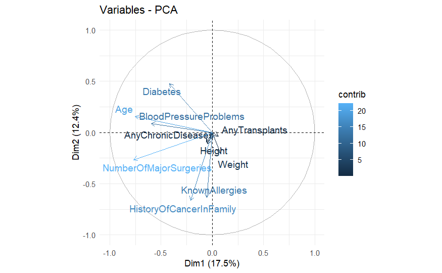

```r
# PCA Loadings Plot

library(factoextra)

# Plot the variable loadings (contributions of variables to PCs)
fviz_pca_var(
  model_pca,            # the PCA model you created
  col.var = "contrib",  # color arrows based on contribution (more important = darker)
  repel = TRUE          # avoid overlapping text labels
) +
  theme_minimal()
```

NumberOfMajorSurgeries:

- Long arrow pointing down-left (negative PC1 and PC2).Contributes strongly to both components, especially PC1.

Age and Diabetes:

- Long arrows pointing up-left (negative PC1, positive PC2).Also contribute significantly.

Weight:

- Short arrow pointing down-right (positive PC1, negative PC2).Very weak influence on PC1 and PC2.

Height:

- Very short arrow mostly pointing downward.Very small contribution.

The loadings plot reveals that **NumberOfMajorSurgeries**, **Age**, and **Diabetes** contribute most strongly to the first two principal components. Their long vectors indicate high variance in these features. In contrast, variables like **Weight** and **Height** show very small arrows near the origin, suggesting limited influence in this 2D space. The directions also highlight correlations — for example, Age and Diabetes are positively related and negatively correlated with Weight. These patterns help us understand the structure of variance in the dataset.

## Reconstructing Variables

```r
library(data.table)
# the original standardized variables for the first row (person)
original_values <- data.table(Variable = colnames(X_scaled),
                              Value = round(as.numeric(X_scaled[1, ]), 2))
print(original_values)
```

| Variable | Value |
| --- | --- |
| Age | 0.23 |
| Diabetes | -0.85 |
| BloodPressureProblems | -0.94 |
| AnyTransplants | -0.24 |
| AnyChronicDiseases | -0.47 |
| Height | -1.31 |
| Weight | -1.40 |
| KnownAllergies | -0.52 |
| HistoryOfCancerInFamily | -0.36 |
| NumberOfMajorSurgeries | -0.89 |

```r
# Project the first observation into PC space (using all 10 PCs)
# This gives us the Principal Component coordinates (V^T * x)

PC_coordinates_all <- t(as.matrix(model_pca$rotation)) %*% as.matrix(X_scaled)[1, ]
PC_coordinates_all <- data.table(PC = paste0("PC", 1:10),
                                 Value = round(as.numeric(PC_coordinates_all), 2))
print(PC_coordinates_all)
```

| PC | Value |
| --- | --- |
| PC1 | 1.13 |
| PC2 | 0.76 |
| PC3 | 0.54 |
| PC4 | -1.42 |
| PC5 | -0.51 |
| PC6 | -0.14 |
| PC7 | 0.19 |
| PC8 | 0.16 |
| PC9 | 1.37 |
| PC10 | -0.65 |

```r
# Reconstruct the original standardized values using ALL PCs
# Formula: V * V^T * x

x_reconstructed_all <- as.matrix(model_pca$rotation) %*%
                       t(as.matrix(model_pca$rotation)) %*%
                       as.matrix(X_scaled)[1, ]

x_reconstructed_all <- data.table(Variable = colnames(X_scaled),
                                  Value = round(as.numeric(x_reconstructed_all), 2))
print(x_reconstructed_all)
```

| Variable | Value |
| --- | --- |
| Age | 0.23 |
| Diabetes | -0.85 |
| BloodPressureProblems | -0.94 |
| AnyTransplants | -0.24 |
| AnyChronicDiseases | -0.47 |
| Height | -1.31 |
| Weight | -1.40 |
| KnownAllergies | -0.52 |
| HistoryOfCancerInFamily | -0.36 |
| NumberOfMajorSurgeries | -0.89 |

```r
# Now reduce dimensionality to 8 PCs (based on the earlier cumulative variance plot)
V_reduced <- as.matrix(model_pca$rotation[, 1:8])

# Project person 1 into reduced PC space (8 PC coordinates)
PC_coordinates_8 <- t(V_reduced) %*% as.matrix(X_scaled)[1, ]
PC_coordinates_8 <- data.table(PC = paste0("PC", 1:8),
                               Value = round(as.numeric(PC_coordinates_8), 2))
print(PC_coordinates_8)
```

| PC | Value |
| --- | --- |
| PC1 | 1.13 |
| PC2 | 0.76 |
| PC3 | 0.54 |
| PC4 | -1.42 |
| PC5 | -0.51 |
| PC6 | -0.14 |
| PC7 | 0.19 |
| PC8 | 0.16 |

```r
# Reconstruct the original variables using only 8 PCs (approximation)
x_reconstructed_8 <- V_reduced %*%
                     t(V_reduced) %*%
                     as.matrix(X_scaled)[1, ]

x_reconstructed_8 <- data.table(Variable = colnames(X_scaled),
                                Value = round(as.numeric(x_reconstructed_8), 2))
print(x_reconstructed_8)
```

| Variable | Value |
| --- | --- |
| Age | -0.77 |
| Diabetes | -0.25 |
| BloodPressureProblems | -0.10 |
| AnyTransplants | -0.08 |
| AnyChronicDiseases | -0.26 |
| Height | -1.02 |
| Weight | -1.29 |
| KnownAllergies | -0.26 |
| HistoryOfCancerInFamily | -0.42 |
| NumberOfMajorSurgeries | -0.90 |

PCA with 8 components gives a good approximation, especially for certain variables. Some loss of detail is expected — that’s the trade-off in dimensionality reduction. For most variables like Weight, Height, Surgeries, and HistoryOfCancerInFamily, the reconstruction is quite close. For some others (e.g., Age, BloodPressureProblems, Diabetes), the reconstruction error is larger, especially for Age.

```r
# Measure reconstruction error across all data points, using MAE

# Create a list to store the results for each number of PCs used
results <- list()

# Loop through 1 to 10 PCs to see how many are needed for a good reconstruction
for (pcs in 1:10) {

  # Reconstruct the data using only the first `pcs` principal components
  reconstructed <- as.matrix(model_pca$rotation[, 1:pcs]) %*%
                   t(as.matrix(model_pca$rotation[, 1:pcs])) %*%
                   t(as.matrix(X_scaled))

  # Calculate MAE = average absolute difference between original and reconstructed
  mae <- mean(rowMeans(abs(t(as.matrix(X_scaled)) - reconstructed)))

  # Store the result (how many PCs and what MAE it gave)
  results[[pcs]] <- data.table("PCs_used" = pcs,
                               "MAE" = mae)
}

# Combine results into one data table
dt_reconstruction <- rbindlist(results)

# Show the result rounded to 2 decimals, ordered by number of PCs
print(round(dt_reconstruction[order(-PCs_used)], 2))
```

| PCs_used | MAE |
| --- | --- |
| 10 | 0.00 |
| 9 | 0.11 |
| 8 | 0.24 |
| 7 | 0.32 |
| 6 | 0.40 |
| 5 | 0.48 |
| 4 | 0.52 |
| 3 | 0.58 |
| 2 | 0.62 |
| 1 | 0.68 |

PCA reconstruction results show that using **8 principal components** preserves most of the information in the original data with a mean absolute reconstruction error of only **~0.24**. This suggests that dimensionality can be reduced from 10 to 8 without a substantial loss in data quality, supporting the idea of using the first 8 PCs in subsequent modeling steps.

## PCA: Linear Model

```r
# Convert the first 8 principal components into a data frame
X_pc8 <- as.data.frame(model_pca$x[, 1:8])

# Add the target variable PremiumPrice
X_pc8$PremiumPrice <- data$PremiumPrice

# Train linear model using the 8 principal components
model_lm_pc8 <- lm(PremiumPrice ~ ., data = X_pc8)

# Predict on training set
pred_train_lm_pc8 <- predict(model_lm_pc8, newdata = X_pc8)

# Calculate training RMSE
rmse_train_lm_pc8 <- sqrt(mean((pred_train_lm_pc8 - X_pc8$PremiumPrice)^2))

library(caret)

# Define CV settings
train_control <- trainControl(method = "cv", number = 5)

# Train model using caret to get CV RMSE
caret_lm_pc8 <- train(PremiumPrice ~ ., data = X_pc8,
                      method = "lm",
                      trControl = train_control)

# Extract CV RMSE
cv_rmse_lm_pc8 <- caret_lm_pc8$results$RMSE
print(paste("CV RMSE:", round(cv_rmse_lm_pc8, 2)))
```

```
[1] "CV RMSE: 4673.02"
```

```r
print(paste("Training RMSE:", round(rmse_train_lm_pc8, 2)))
```

```
[1] "Training RMSE: 4625.12"
```

## PCA: Regression Tree

```r
library(rpart)
library(rpart.plot)

# Fit a regression tree model
model_tree_pc8 <- rpart(PremiumPrice ~ ., data = X_pc8, method = "anova")

# Predict on training data
pred_train_tree_pc8 <- predict(model_tree_pc8, newdata = X_pc8)

# Calculate training RMSE
rmse_train_tree_pc8 <- sqrt(mean((pred_train_tree_pc8 - X_pc8$PremiumPrice)^2))

# Define cross-validation control
train_control <- trainControl(method = "cv", number = 5)

# Train the tree model with CV using caret
caret_tree_pc8 <- train(PremiumPrice ~ .,
                        data = X_pc8,
                        method = "rpart",
                       trControl = train_control)
```

```
G2;H2;Warningh in nominalTrainWorkflow(x = x, y = y, wts = weights, info = trainInfo,  :
  There were missing values in resampled performance measures.g
```

```r
# caret automatically tries different complexity parameter (cp) values during training
# Get lowest CV RMSE
best_cv_rmse_tree_pc8 <- min(caret_tree_pc8$results$RMSE)
print(paste("Best CV RMSE:", round(best_cv_rmse_tree_pc8, 2)))
```

```
[1] "Best CV RMSE: 5608.39"
```

```r
print(paste("Training RMSE:", round(rmse_train_tree_pc8, 2)))
```

```
[1] "Training RMSE: 4211.62"
```

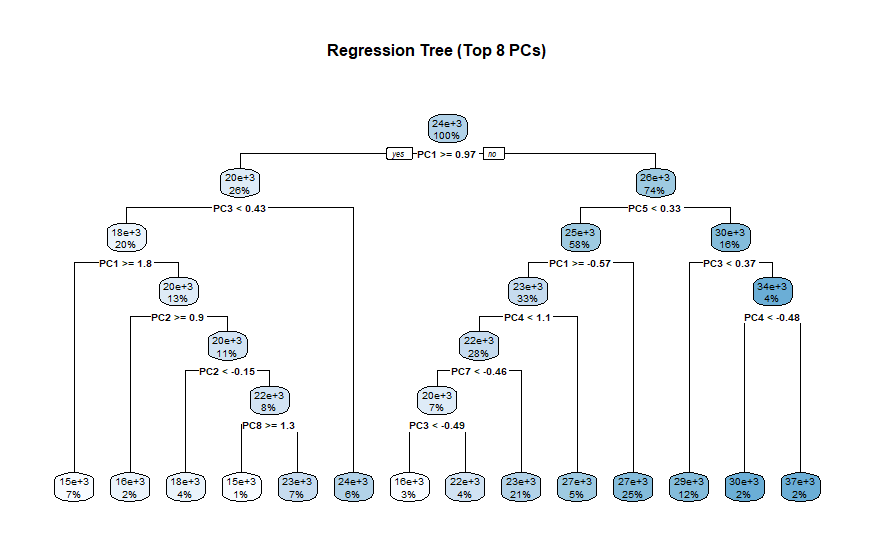

```r
# Plot the tree
rpart.plot(model_tree_pc8, main = "Regression Tree (Top 8 PCs)")
```

## PCA: Random Forest

```r
library(randomForest)
library(caret)

# Set seed for reproducibility
set.seed(123)

# Recreate top 8 principal components using X_scaled
model_pca <- prcomp(X_scaled, center = FALSE, scale. = FALSE)

# Get top 8 PCs
pc_data_8 <- as.data.frame(model_pca$x[, 1:8])

# Combine PCs with target variable (PremiumPrice)
data_rf_pc8 <- cbind(pc_data_8, PremiumPrice = data$PremiumPrice)


# Train Random Forest model with specified hyperparameters
rf_model_pc8 <- randomForest(
  PremiumPrice ~ .,              # Formula: Predict PremiumPrice using all PCs
  data = data_rf_pc8,            # Data with top 8 PCs
  mtry = 6,                      # Number of predictors considered at each split(Selected previously)
  ntree = 500                    # Number of trees in the forest
)

# Make predictions on training data to calculate Training RMSE
pred_train_rf_pc8 <- predict(rf_model_pc8, newdata = data_rf_pc8)
rmse_train_rf_pc8 <- sqrt(mean((pred_train_rf_pc8 - data_rf_pc8$PremiumPrice)^2))


# 5-fold Cross-Validation to get CV RMSE
train_control_rf <- trainControl(method = "cv", number = 5)

# Use caret to run cross-validation with fixed mtry and ntree
rf_cv_model_pc8 <- train(
  PremiumPrice ~ .,
  data = data_rf_pc8,
  method = "rf",
  trControl = train_control_rf,
  tuneGrid = data.frame(mtry = 6),  # fixed mtry = 6
  ntree = 500,
  importance = TRUE
)

#Extract CV RMSE
cv_rmse_rf_pc8 <- rf_cv_model_pc8$results$RMSE
print(paste("CV RMSE:", round(cv_rmse_rf_pc8, 2)))
```

```
[1] "CV RMSE: 4160.99"
```

```r
print(paste("Training RMSE:", round(rmse_train_rf_pc8, 2)))
```

```
[1] "Training RMSE: 1725.55"
```

This considerable gap indicates that while the model fits the training data very well, it generalizes less effectively to unseen data; a common sign of overfitting. Though PCA was used to reduce dimensionality, some complexity and variance remain in the transformed features that the model may be overly sensitive to.

## PCA: Gradient Boosting (GBM)

```r
library(gbm)
library(caret)

# Prepare data
X_pc <- pc_data_8  # top 8 PCs
y_pc <- y          # PremiumPrice as target

# Combine into a dataframe
data_gbm_pc8 <- data.frame(X_pc, PremiumPrice = y_pc)

# Train the GBM model using the selected hyperparameters
set.seed(123)
gbm_model_pc8 <- gbm(
  formula = PremiumPrice ~ .,
  distribution = "gaussian",
  data = data_gbm_pc8,
  n.trees = 500,
  interaction.depth = 5,
  shrinkage = 0.01,
  n.minobsinnode = 10,
  verbose = FALSE
)

# Predict on training set
train_preds_gbm_pc8 <- predict(gbm_model_pc8, newdata = data_gbm_pc8, n.trees = 500)

# Calculate training RMSE
rmse_train_gbm_pc8 <- sqrt(mean((train_preds_gbm_pc8 - y_pc)^2))


# Cross-validation setup
set.seed(123)
cv_folds <- createFolds(y_pc, k = 5, list = TRUE)
cv_results <- c()

for (i in 1:5) {
  train_idx <- unlist(cv_folds[-i])
  test_idx <- unlist(cv_folds[i])

  train_data <- data_gbm_pc8[train_idx, ]
  test_data  <- data_gbm_pc8[test_idx, ]

  # Fit GBM on training folds
  gbm_cv <- gbm(
    formula = PremiumPrice ~ .,
    distribution = "gaussian",
    data = train_data,
    n.trees = 500,
    interaction.depth = 5,
    shrinkage = 0.01,
    n.minobsinnode = 10,
    verbose = FALSE
  )

  # Predict on validation fold
  preds <- predict(gbm_cv, newdata = test_data, n.trees = 500)
  rmse <- sqrt(mean((preds - test_data$PremiumPrice)^2))
  cv_results[i] <- rmse
}

# Display results
print(paste("Training RMSE:", round(rmse_train_gbm_pc8, 2)))
```

```
[1] "Training RMSE: 3590.84"
```

```r
print(paste("CV RMSE:", round(mean(cv_results), 2)))
```

```
[1] "CV RMSE: 4282.04"
```

## PCA: Neural Network; 2 Hidden Layers (16 + 8 neurons)

```r
library(keras3)

# Input features (PCs) and target
X_nn <- pc_data_8
y_nn <- y

# Clear keras backend session
keras3::clear_session()
```

```
G2;H2;WARNINGh:tensorflow:From C:\Users\Lenovo\DOCUME~1\VIRTUA~1\r-keras\lib\site-packages\keras\src\backend\common\global_state.py:82: The name tf.reset_default_graph is deprecated. Please use tf.compat.v1.reset_default_graph instead.

g
```

```r
# Ensure X_nn is a numeric matrix
X_nn <- as.matrix(data.frame(X_nn))
storage.mode(X_nn) <- "numeric"


# Normalize inputs using keras normalization layer
normalize_layer <- layer_normalization()
normalize_layer %>% adapt(X_nn)

# Build the neural network model
model_nn_pc <- keras_model_sequential() %>%
  normalize_layer %>%
  layer_dense(units = 16, activation = "relu", name = "HiddenLayer1") %>%
  layer_dense(units = 8, activation = "relu", name = "HiddenLayer2") %>%
  layer_dense(units = 1, name = "OutputLayer")

# Compile the model
model_nn_pc %>% compile(
  loss = "mse",
  optimizer = "adam"
)

# Fit the model (training)
set.seed(123)
model_history_pc <- model_nn_pc %>% fit(
  x = X_nn,
  y = y_nn,
  epochs = 500,
  verbose = 0
)

# Training predictions and RMSE
train_preds_nn_pc <- predict(model_nn_pc, X_nn)
```

```
 1/31 ━━━━━━━━━━━━━━━━━━━━ 2s 76ms/step
31/31 ━━━━━━━━━━━━━━━━━━━━ 0s 3ms/step
31/31 ━━━━━━━━━━━━━━━━━━━━ 0s 4ms/step
```

```r
rmse_train_nn_pc <- sqrt(mean((train_preds_nn_pc - y_nn)^2))


# Cross-validation RMSE (5-fold)
set.seed(123)
cv_folds <- createFolds(y_nn, k = 5)
cv_rmse_nn_pc <- c()

for (i in 1:5) {
  train_idx <- unlist(cv_folds[-i])
  test_idx  <- unlist(cv_folds[i])

  X_train <- X_nn[train_idx, ]
  y_train <- y_nn[train_idx]
  X_test  <- X_nn[test_idx, ]
  y_test  <- y_nn[test_idx]

  # Normalize again for each fold
  norm_layer_cv <- layer_normalization()
  norm_layer_cv %>% adapt(X_train)

  # Build model again (new model per fold)
  model_cv <- keras_model_sequential() %>%
    norm_layer_cv %>%
    layer_dense(units = 16, activation = "relu") %>%
    layer_dense(units = 8, activation = "relu") %>%
    layer_dense(units = 1)

  model_cv %>% compile(
    loss = "mse",
    optimizer = "adam"
  )

  # Fit the model on training fold
  model_cv %>% fit(x = X_train, y = y_train, epochs = 500, verbose = 0)

  # Predict on test fold
  preds <- predict(model_cv, X_test)
  rmse <- sqrt(mean((preds - y_test)^2))
  cv_rmse_nn_pc[i] <- rmse
}
```

```
1/7 ━━━━━━━━━━━━━━━━━━━━ 0s 91ms/step
7/7 ━━━━━━━━━━━━━━━━━━━━ 0s 15ms/step
7/7 ━━━━━━━━━━━━━━━━━━━━ 0s 20ms/step

1/7 ━━━━━━━━━━━━━━━━━━━━ 0s 86ms/step
7/7 ━━━━━━━━━━━━━━━━━━━━ 0s 14ms/step
7/7 ━━━━━━━━━━━━━━━━━━━━ 0s 20ms/step

1/7 ━━━━━━━━━━━━━━━━━━━━ 0s 72ms/step
7/7 ━━━━━━━━━━━━━━━━━━━━ 0s 9ms/step
7/7 ━━━━━━━━━━━━━━━━━━━━ 0s 13ms/step

1/7 ━━━━━━━━━━━━━━━━━━━━ 0s 92ms/step
7/7 ━━━━━━━━━━━━━━━━━━━━ 0s 15ms/step
7/7 ━━━━━━━━━━━━━━━━━━━━ 0s 22ms/step

1/7 ━━━━━━━━━━━━━━━━━━━━ 0s 75ms/step
7/7 ━━━━━━━━━━━━━━━━━━━━ 0s 12ms/step
7/7 ━━━━━━━━━━━━━━━━━━━━ 0s 18ms/step
```

```r
# Show results
print(paste("Training RMSE:", round(rmse_train_nn_pc, 2)))
```

```
[1] "Training RMSE: 4509.83"
```

```r
print(paste("CV RMSE:", round(mean(cv_rmse_nn_pc), 2)))
```

```
[1] "CV RMSE: 4775.13"
```

# Model Selection

```r
# Load required libraries
library(data.table)
library(knitr)  # For clean printing

# Create a data table of model results
model_results <- data.table(
  Model = c("Linear Model", "Regression Tree", "Random Forest",
            "Gradient Boosting", "Neural Network"),
  `Train RMSE (No PCA)` = c(3847.17, 3224.39, 1588.92, 2853.15, 3733.3),
  `CV RMSE (No PCA)` = c(3881.83, 3379.69, 3071.27, 3223.96, 4008.88),
  `Train RMSE (8 PCs)` = c(4625.12, 4211.62, 1725.55, 3590.84, 4509.83),
  `CV RMSE (8 PCs)` = c(4673.02, 5608.39, 4160.99, 4282.04, 4775.13)
)

# Print the table nicely
kable(model_results, caption = "Model Comparison: RMSE With and Without PCA")
```

Model Comparison: RMSE With and Without PCA

| Model | Train RMSE (No PCA) | CV RMSE (No PCA) | Train RMSE (8 PCs) | CV RMSE (8 PCs) |
| --- | --- | --- | --- | --- |
| Linear Model | 3847.17 | 3881.83 | 4625.12 | 4673.02 |
| Regression Tree | 3224.39 | 3379.69 | 4211.62 | 5608.39 |
| Random Forest | 1588.92 | 3071.27 | 1725.55 | 4160.99 |
| Gradient Boosting | 2853.15 | 3223.96 | 3590.84 | 4282.04 |
| Neural Network | 3733.30 | 4008.88 | 4509.83 | 4775.13 |

```r
#Chart of Results

library(data.table)
library(ggplot2)
library(tidyr)
library(dplyr)

# Create the raw results data in wide format
model_results <- data.table(
  Model = c("Linear Model", "Regression Tree", "Random Forest",
            "Gradient Boosting", "Neural Network"),

  Train_No_PCA = c(3847.17, 3224.39, 1588.92, 2853.15, 3733.3),
  CV_No_PCA    = c(3881.83, 3379.69, 3071.27, 3223.96, 4008.88),

  Train_PCA    = c(4625.12, 4211.62, 1725.55, 3590.84, 4509.83),
  CV_PCA       = c(4673.02, 5608.39, 4160.99, 4282.04, 4775.13)
)

# Reshape into long format
model_long <- melt(model_results, id.vars = "Model",
                   variable.name = "Type", value.name = "RMSE")

# Split Type column into Metric and PCA columns
model_long <- separate(model_long, Type, into = c("Metric", "PCA"), sep = "_")
```

```
G2;H2;Warningh: Expected 2 pieces. Additional pieces discarded in 10 rows [1, 2, 3, 4, 5, 6, 7, 8, 9, 10].g
```

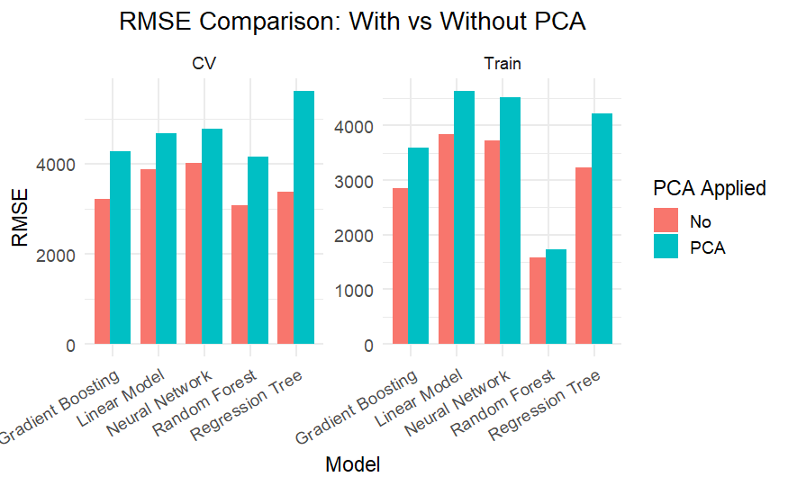

```r
# Faceted bar plot
ggplot(model_long, aes(x = Model, y = RMSE, fill = PCA)) +
  geom_bar(stat = "identity", position = position_dodge(width = 0.7)) +
  facet_wrap(~ Metric, scales = "free_y") +
  labs(
    title = "RMSE Comparison: With vs Without PCA",
    x = "Model",
    y = "RMSE",
    fill = "PCA Applied"
  ) +
  theme_minimal(base_size = 14) +
  theme(
    axis.text.x = element_text(angle = 30, hjust = 1),
    plot.title = element_text(hjust = 0.5)
  )
```

Model Comparison Based on CV RMSE:

we conclude that dimensionality reduction via PCA was **not beneficial** in this project, as the original variables already had strong predictive power and relatively low dimensionality.

**The best model** is the one with the lowest CV-RMSE, because it best reflects expected performance on future (test) data. Best Model Overall is **Random Forest without PCA**. It has the lowest CV RMSE (3071.27).

## The expected loss of the best model on the test set

```r
library(Metrics) #RMSE
library(randomForest)
library(caret)
# Use the trained model (rf_tuned) to predict on the test set
test_pred_rf <- predict(rf_tuned, newdata = test)

# Calculate RMSE between predicted and actual PremiumPrice on test set
test_rmse_rf <- RMSE(test_pred_rf, test$PremiumPrice)

# Print final result
cat("Test RMSE (Expected Loss):", round(test_rmse_rf, 2), "\n")
```

```
Test RMSE (Expected Loss): 1724.5
```

This means that on average, the Random Forest model (mtry = 6) makes a **prediction error of ~₹1724.50** when predicting the insurance premium price on new, **unseen data**. This value answers this question: “If I use this model in the real world to predict new customers’ premium prices, how far off will my predictions be on average?” The model performed even better on the test set than during cross-validation on the training set CV-RMSE: 3071